# Ecosystem Service Climate Regulation in Cities | Norway

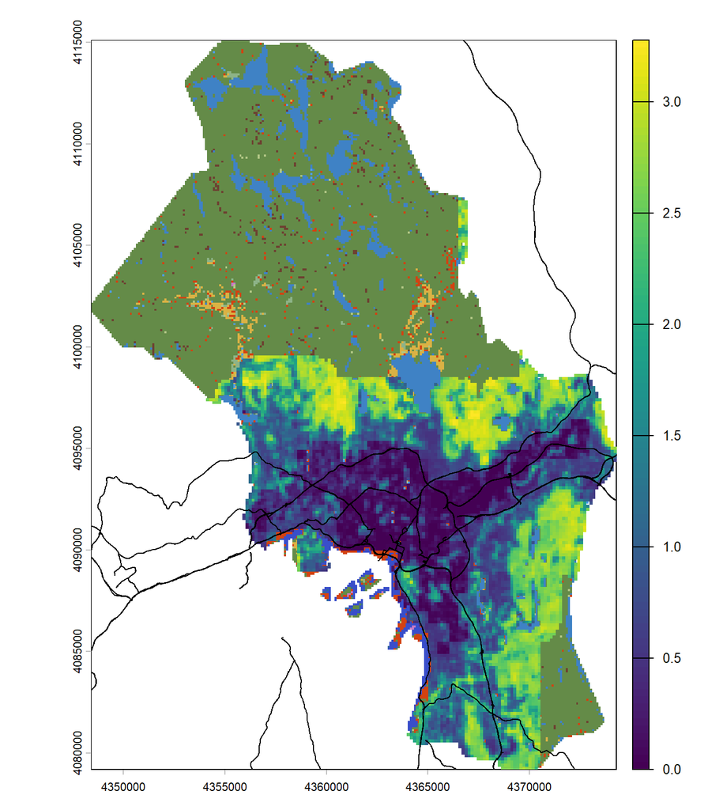

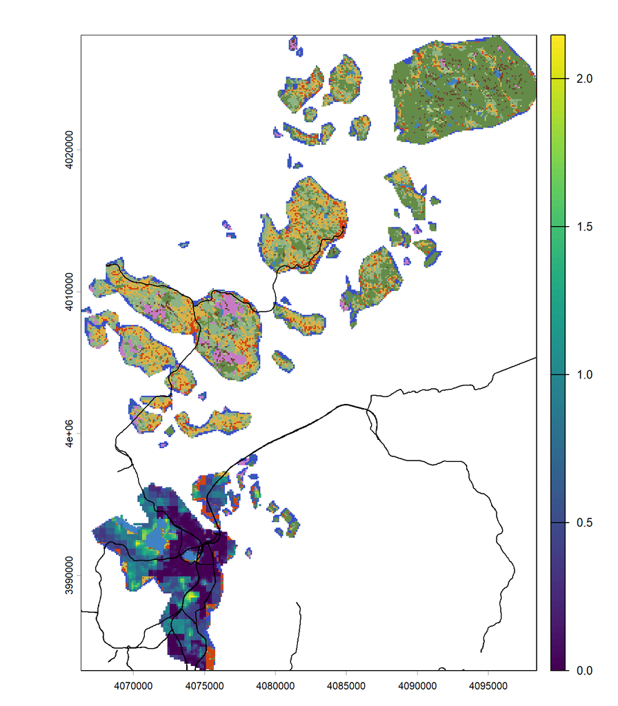

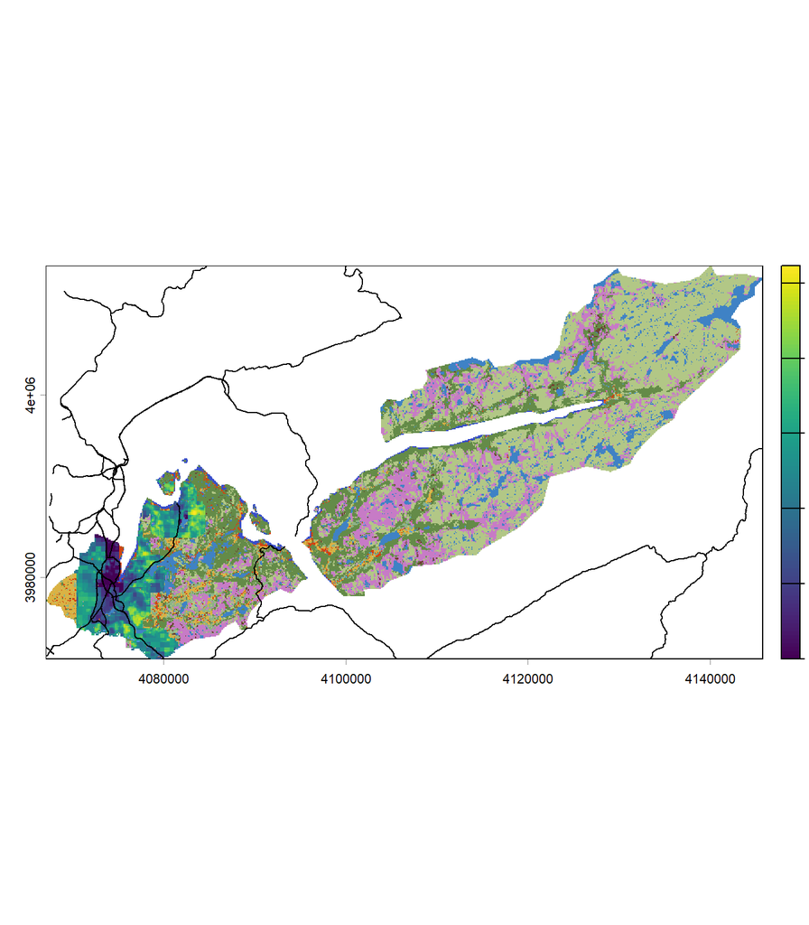

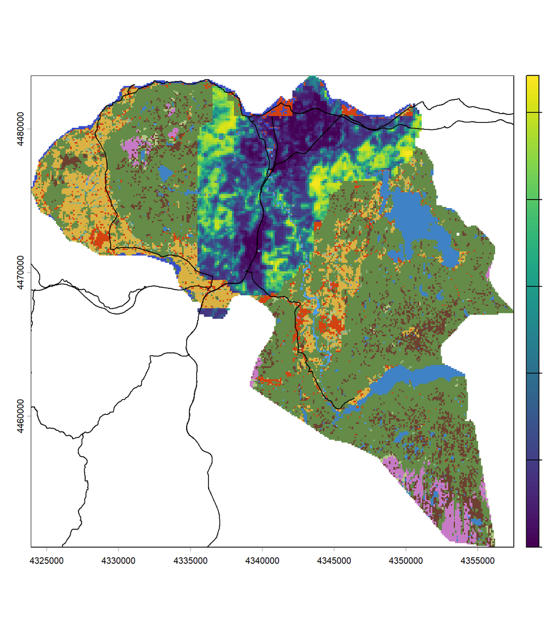

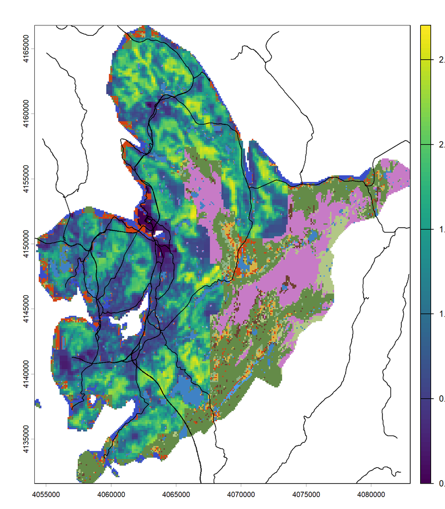

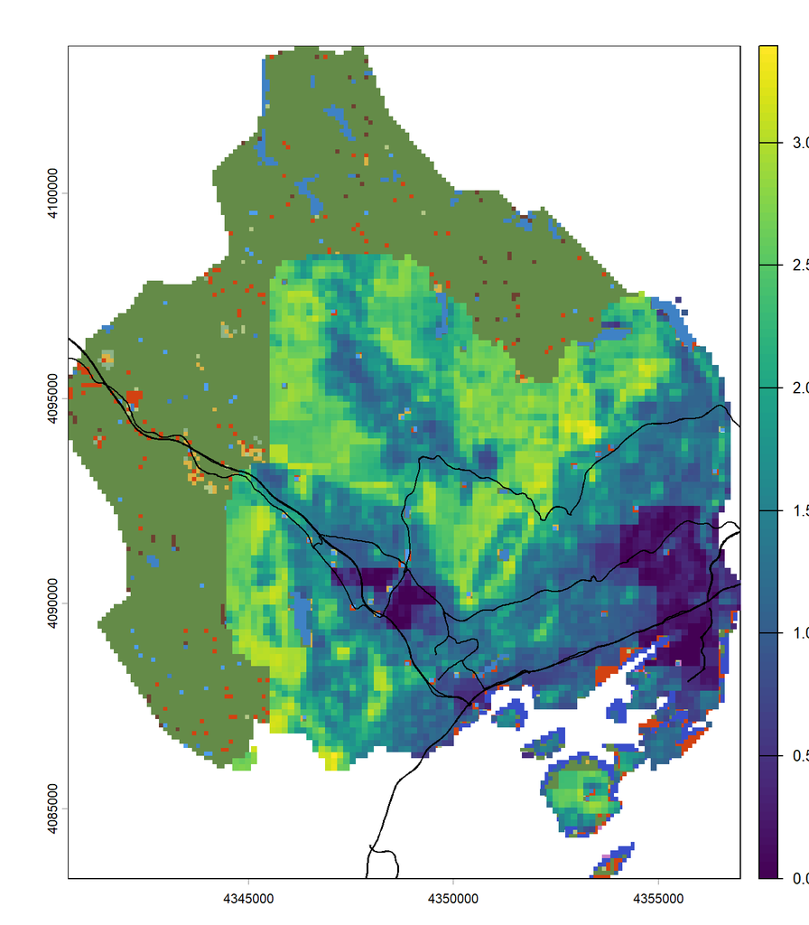

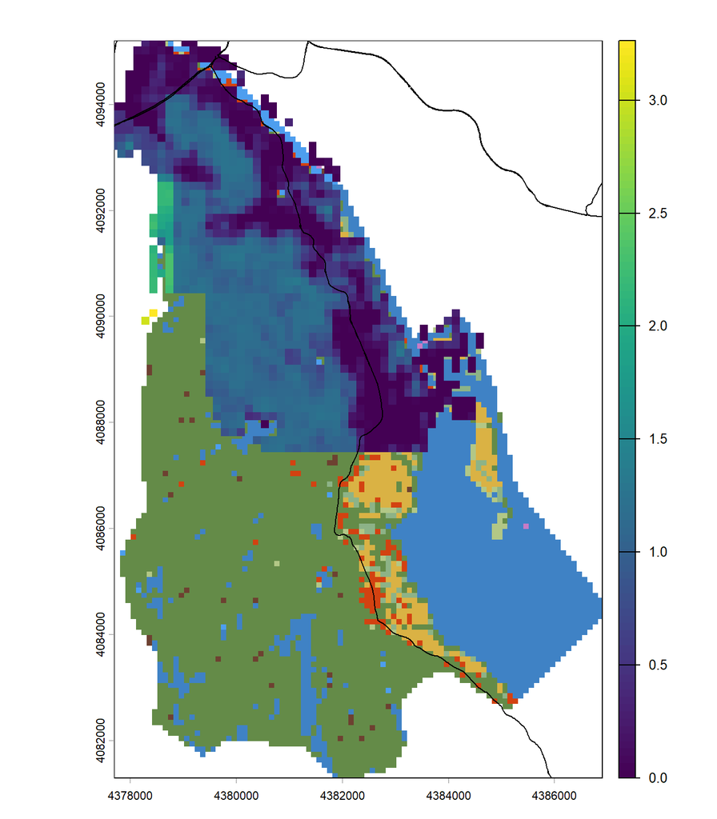

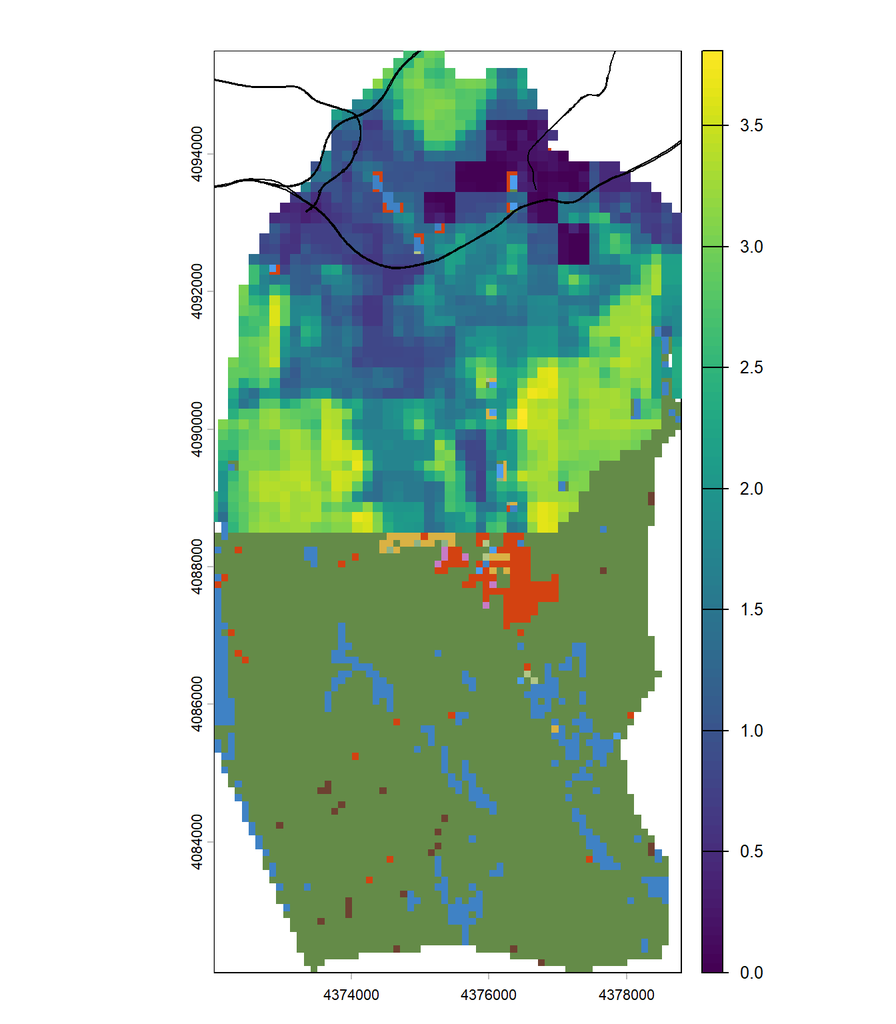

```r
j=2
for(i in 1:nrow(cityb_buf_m_l[[j]])){
  plot(crop(lcm,cityb_l[[j]][i,],mask=T),legend=F)
  plot(crop(cooling_stack_n[[j]], cityb_buf_l[[j]][i,],mask=T),main=paste(cityb_buf_l[[j]]$LAU_NAME[i],"cooling","month",mdr[j]), add=T,legend=T)
  plot(roads_list[[i]],add=T)
}
```

## 6.3 Supply tables

### 6.3.1 Eurostat version

So here now we aggregate the cooling rasters by NUTS2 area, NUTS0 area, and ecosystem type. The 150m buffers imply that those NUTS2 areas that do not include city LAUs but that do have a border with city LAUs, do include cooling pixels. INCA does not address this problem. We set those cases to zero.

The indicators we report in our supply and use tables are what INCA calls “simple average” for the by-ecosystem values and what INCA calls “weighted average” for cooling across all ecosystem types.

```r
gc()
# now cooling by nuts and ecosystem
# Import Norway NUTs2 shape
n2shp<-terra::vect(file.path(d_fp,"Norway_files","NUTS2021_NO_LVL2_wosvalbard","NUTS2021_NO_LVL2_wos.shp"))
n2shp <- project(n2shp,crs(lcm))
# rasterize the shape
n2r_no <- terra::rasterize(n2shp,mask_stack,field="NUTS_ID")
# now make a loop across months
stl<-list()
for(j in 1:length(mdr)){
  # Step 1: Make a stack of the relevant data and move it into a dataframe
  astack <- c(
  terra::crop(cooling_stack_e[[j]],lcm2),
  n2r_no,
  lcm2)
  names(astack)<-c("cooling","region","lcm")
  adf<-as.data.frame(astack)
  clean_adf <- adf %>% drop_na()
  # Step 2: Retrieve all the different summary statistics we want
  # means by region and ecosystem type
  mean_by_region_es <- clean_adf %>%
    group_by(region,lcm) %>%
    summarise(cooling = mean(cooling))
  mean_by_es <- clean_adf %>%
    select(-region) %>%
    group_by(lcm) %>%
    summarise(cooling = mean(cooling)) %>%
    mutate(region = "NO") %>%
    relocate(region,.before=lcm)
  # total means by NUTS2
  mean_by_region <- clean_adf %>%
    group_by(region) %>%
    summarise(cooling = mean(cooling)) %>%
    mutate(lcm="All") %>%
    relocate(lcm,.after=region)
  # total mean for the whole country NUTS0
  mean_overall <- clean_adf %>% select(cooling) %>%
    summarise(cooling=mean(cooling)) %>%
    mutate(region = "NO",lcm = "All") %>%
    relocate(cooling,.after =lcm)
  # put together
  mean_vals <- rbind(mean_by_es,mean_overall,mean_by_region_es,mean_by_region) %>%
    filter(region !="NO09") %>%
    pivot_wider(names_from=lcm,values_from = cooling) %>%
    left_join(n2shp %>% as.data.frame() %>% select(NUTS_ID,NUTS_NAME),
            by = join_by(region == NUTS_ID)) %>%
    rename(Name = NUTS_NAME) %>%
    relocate(Name,.after=region) %>%
    rename(Region = region)
  mean_vals$Name[mean_vals$Region=="NO"]<-"Norge"
  # put into our list
  stl[[j]]<-mean_vals
  # Step 3: clean up
  rm(astack,adf,clean_adf,mean_overall,mean_by_region,mean_by_es,mean_by_region_es,mean_vals)
}
names(stl)<-mdr
stl_e<-stl
rm(stl)
```

Here are the results for June (rounded)

```r
kable(stl_e[[1]] %>% mutate(across(where(is.numeric), ~ round(.x, 2))))
```

| Region | Name | Settlements and other artificial areas | Cropland | Grassland | Forest and woodlands | Heathlands and shrub | Sparsely vegetated ecosystems | Inland wetlands | Coastal beaches, dunes and wetlands | All |
| --- | --- | --- | --- | --- | --- | --- | --- | --- | --- | --- |
| NO | Norge | 0.78 | 1.04 | 1.27 | 1.97 | 0.64 | 0.31 | 1.23 | 1.02 | 1.28 |
| NO06 | Trøndelag | 0.64 | 1.04 | 1.27 | 1.37 | 0.60 | 0.88 | 0.98 | 1.25 | 1.16 |
| NO08 | Oslo og Viken | 0.72 | 1.07 | 1.29 | 2.28 | 0.82 | 1.02 | 2.04 | 0.98 | 1.81 |
| NO0A | Vestlandet | 0.91 | 1.03 | 1.27 | 2.01 | 0.65 | 0.28 | 1.47 | 1.00 | 1.06 |

Here are the results for July (rounded)

```r
kable(stl_e[[2]] %>% mutate(across(where(is.numeric), ~ round(.x, 2))))
```

| Region | Name | Settlements and other artificial areas | Cropland | Grassland | Forest and woodlands | Heathlands and shrub | Sparsely vegetated ecosystems | Inland wetlands | Coastal beaches, dunes and wetlands | All |
| --- | --- | --- | --- | --- | --- | --- | --- | --- | --- | --- |
| NO | Norge | 0.61 | 0.70 | 0.70 | 1.55 | 0.31 | 0.14 | 0.90 | 0.64 | 0.95 |
| NO06 | Trøndelag | 0.51 | 0.78 | 1.04 | 1.24 | 0.41 | 0.70 | 0.83 | 0.96 | 1.01 |
| NO08 | Oslo og Viken | 0.77 | 1.24 | 1.36 | 2.27 | 0.92 | 1.10 | 2.01 | 1.27 | 1.82 |
| NO0A | Vestlandet | 0.48 | 0.51 | 0.64 | 0.97 | 0.30 | 0.10 | 0.73 | 0.53 | 0.51 |

### 6.3.2 Strict urban version

Same as in the previous section, but based on stricter urban definition.

```r
gc()
# now cooling by nuts and ecosystem
# Import Norway NUTs2 shape
n2shp<-terra::vect(file.path(d_fp,"Norway_files","NUTS2021_NO_LVL2_wosvalbard","NUTS2021_NO_LVL2_wos.shp"))
n2shp <- project(n2shp,crs(lcm))
# rasterize the shape
n2r_no <- terra::rasterize(n2shp,mask_stack,field="NUTS_ID")
# need to extend the stricter version so it is as large as the previous map
# this just adds NA colums on the right and on the left.
cooling_stack_n <- extend(
  cooling_stack_n,
  ext(cooling_stack_e)
)
# now make a loop across months
stl<-list()
for(j in 1:length(mdr)){
  # Step 1: Make a stack of the relevant data and move it into a dataframe
  astack <- c(
  terra::crop(cooling_stack_n[[j]],lcm2),
  n2r_no,
  lcm2)
  names(astack)<-c("cooling","region","lcm")
  adf<-as.data.frame(astack)
  clean_adf <- adf %>% drop_na()
  # Step 2: Retrieve all the different summary statistics we want
  # means by region and ecosystem type
  mean_by_region_es <- clean_adf %>%
    group_by(region,lcm) %>%
    summarise(cooling = mean(cooling))
  mean_by_es <- clean_adf %>%
    select(-region) %>%
    group_by(lcm) %>%
    summarise(cooling = mean(cooling)) %>%
    mutate(region = "NO") %>%
    relocate(region,.before=lcm)
  # total means by NUTS2
  mean_by_region <- clean_adf %>%
    group_by(region) %>%
    summarise(cooling = mean(cooling)) %>%
    mutate(lcm="All") %>%
    relocate(lcm,.after=region)
  # total mean for the whole country NUTS0
  mean_overall <- clean_adf %>% select(cooling) %>%
    summarise(cooling=mean(cooling)) %>%
    mutate(region = "NO",lcm = "All") %>%
    relocate(cooling,.after =lcm)
  # put together
  mean_vals <- rbind(mean_by_es,mean_overall,mean_by_region_es,mean_by_region) %>%
    filter(region !="NO09") %>%
    pivot_wider(names_from=lcm,values_from = cooling) %>%
    left_join(n2shp %>% as.data.frame() %>% select(NUTS_ID,NUTS_NAME),
            by = join_by(region == NUTS_ID)) %>%
    rename(Name = NUTS_NAME) %>%
    relocate(Name,.after=region) %>%
    rename(Region = region)
  mean_vals$Name[mean_vals$Region=="NO"]<-"Norge"
  # put into our list
  stl[[j]]<-mean_vals
  # Step 3: clean up
  rm(astack,adf,clean_adf,mean_overall,mean_by_region,mean_by_es,mean_by_region_es,mean_vals)
}
names(stl)<-mdr
stl_n<-stl
rm(stl)
```

Here are the results for June (rounded)

```r
kable(stl_n[[1]] %>% mutate(across(where(is.numeric), ~ round(.x, 2))))
```

| Region | Name | Settlements and other artificial areas | Cropland | Grassland | Forest and woodlands | Heathlands and shrub | Sparsely vegetated ecosystems | Inland wetlands | Coastal beaches, dunes and wetlands | All |
| --- | --- | --- | --- | --- | --- | --- | --- | --- | --- | --- |
| NO | Norge | 0.81 | 1.23 | 1.58 | 2.31 | 1.55 | 1.24 | 2.02 | 1.14 | 1.53 |
| NO06 | Trøndelag | 0.64 | 1.13 | 1.51 | 1.93 | 0.52 | 1.00 | 1.75 | 1.53 | 1.24 |
| NO08 | Oslo og Viken | 0.75 | 1.29 | 1.39 | 2.27 | 0.92 | 1.08 | 1.94 | 1.09 | 1.45 |
| NO0A | Vestlandet | 0.96 | 1.23 | 1.61 | 2.46 | 1.63 | 1.38 | 2.13 | 1.06 | 1.68 |

Here are the results for July (rounded)

```r
kable(stl_n[[2]] %>% mutate(across(where(is.numeric), ~ round(.x, 2))))
```

| Region | Name | Settlements and other artificial areas | Cropland | Grassland | Forest and woodlands | Heathlands and shrub | Sparsely vegetated ecosystems | Inland wetlands | Coastal beaches, dunes and wetlands | All |
| --- | --- | --- | --- | --- | --- | --- | --- | --- | --- | --- |
| NO | Norge | 0.71 | 1.15 | 1.35 | 1.90 | 1.06 | 1.05 | 1.54 | 0.95 | 1.28 |
| NO06 | Trøndelag | 0.50 | 0.79 | 1.22 | 1.75 | 0.42 | 0.79 | 1.53 | 1.13 | 1.05 |
| NO08 | Oslo og Viken | 0.79 | 1.43 | 1.48 | 2.25 | 0.99 | 1.13 | 1.91 | 1.25 | 1.47 |
| NO0A | Vestlandet | 0.67 | 1.15 | 1.35 | 1.60 | 1.08 | 1.08 | 1.49 | 0.83 | 1.18 |

## 6.4 Ecosystem contribution tables

### 6.4.1 Eurostat version

To show how different ecosystems contribute to total cooling in each region, we construct seperate tables to show a decomposition of the (weighted) averages reported in the above section. This is what INCA calls “weighted average” for the by-ecosystem values. The decomposed values are not very insightful on their own, because they reflect the proportion of different ecosystems in each region (if the region consists predominantly of forest, forest will have the largest contribution to cooling). The cooling effectiveness of different ecosystems is much better captured by the values reported in the previous section.

```r
gc()
# decomposed total cooling by ecosystem for each region
# now make a loop across months
cstl<-list()
for(j in 1:length(mdr)){
  # Step 1: Make a stack of the relevant data and move it into a dataframe
astack <- c(
  terra::crop(cooling_stack_e[[j]],lcm2),
  n2r_no,
  lcm2)
names(astack)<-c("cooling","region","lcm")
adf<-as.data.frame(astack)
clean_adf <- adf %>% drop_na()
# Step 2: Retrieve all the different summary statistics we want
# means by region and ecosystem type
mean_by_region_es <- clean_adf %>%
  group_by(region,lcm) %>%
  summarise(cooling = mean(cooling))
mean_by_es <- clean_adf %>%
  select(-region) %>%
  group_by(lcm) %>%
  summarise(cooling = mean(cooling)) %>%
  mutate(region = "NO") %>%
  relocate(region,.before=lcm)
# weights
weights_by_region_es<-clean_adf %>% group_by(region) %>% count(lcm) %>% mutate(weight = n/sum(n)) %>% ungroup()
weights_overall_es<-clean_adf %>% count(lcm) %>% mutate(weight = n/sum(n)) %>% ungroup()

# put together
decomp_by_region_es <- mean_by_region_es %>% left_join(weights_by_region_es) %>%
  mutate(dcmp_cooling = cooling * weight)
decomp_overall_es <- mean_by_es %>% left_join(weights_overall_es) %>%
  mutate(dcmp_cooling = cooling * weight)
decomp_vals <- rbind(decomp_overall_es,decomp_by_region_es) %>%
  filter(region !="NO09") %>%
  select(-c(n,weight,cooling)) %>%
  pivot_wider(names_from=lcm,values_from = dcmp_cooling) %>%
  left_join(n2shp %>% as.data.frame() %>% select(NUTS_ID,NUTS_NAME),
            by = join_by(region == NUTS_ID)) %>%
  rename(Name = NUTS_NAME) %>%
  relocate(Name,.after=region) %>%
  rename(Region = region) %>%
  mutate(All = rowSums(across(`Settlements and other artificial areas`:`Coastal beaches, dunes and wetlands`)))
decomp_vals$Name[decomp_vals$Region=="NO"]<-"Norge"
  # put into our list
  cstl[[j]]<-decomp_vals
  # Step 3: clean up
  rm(astack,adf,clean_adf,mean_by_es,mean_by_region_es,decomp_vals,decomp_overall_es,decomp_by_region_es,weights_overall_es,weights_by_region_es)
}
names(cstl)<-mdr
cstl_e<-cstl
rm(cstl)
```

Here are the contribution results for June (rounded)

```r
kable(cstl_e[[1]] %>% mutate(across(where(is.numeric), ~ round(.x, 2))))
```

| Region | Name | Settlements and other artificial areas | Cropland | Grassland | Forest and woodlands | Heathlands and shrub | Sparsely vegetated ecosystems | Inland wetlands | Coastal beaches, dunes and wetlands | All |
| --- | --- | --- | --- | --- | --- | --- | --- | --- | --- | --- |
| NO | Norge | 0.12 | 0.08 | 0.04 | 0.89 | 0.06 | 0.05 | 0.03 | 0 | 1.28 |
| NO06 | Trøndelag | 0.09 | 0.13 | 0.02 | 0.80 | 0.02 | 0.02 | 0.08 | 0 | 1.16 |
| NO08 | Oslo og Viken | 0.18 | 0.04 | 0.01 | 1.54 | 0.00 | 0.01 | 0.02 | 0 | 1.81 |
| NO0A | Vestlandet | 0.10 | 0.07 | 0.07 | 0.61 | 0.11 | 0.08 | 0.02 | 0 | 1.06 |

Here are the contribution results for July (rounded)

```r
kable(cstl_e[[2]] %>% mutate(across(where(is.numeric), ~ round(.x, 2))))
```

| Region | Name | Settlements and other artificial areas | Cropland | Grassland | Forest and woodlands | Heathlands and shrub | Sparsely vegetated ecosystems | Inland wetlands | Coastal beaches, dunes and wetlands | All |
| --- | --- | --- | --- | --- | --- | --- | --- | --- | --- | --- |
| NO | Norge | 0.09 | 0.05 | 0.02 | 0.70 | 0.03 | 0.02 | 0.02 | 0 | 0.95 |
| NO06 | Trøndelag | 0.07 | 0.10 | 0.01 | 0.72 | 0.01 | 0.01 | 0.07 | 0 | 1.01 |
| NO08 | Oslo og Viken | 0.20 | 0.05 | 0.01 | 1.53 | 0.00 | 0.02 | 0.02 | 0 | 1.82 |
| NO0A | Vestlandet | 0.05 | 0.04 | 0.04 | 0.30 | 0.05 | 0.03 | 0.01 | 0 | 0.51 |

### 6.4.2 Strict urban version

Same as in the previous version, but now based on strict urban areas.

```r
gc()
# decomposed total cooling by ecosystem for each region
# now make a loop across months
cstl<-list()
for(j in 1:length(mdr)){
  # Step 1: Make a stack of the relevant data and move it into a dataframe
astack <- c(
  terra::crop(cooling_stack_n[[j]],lcm2),
  n2r_no,
  lcm2)
names(astack)<-c("cooling","region","lcm")
adf<-as.data.frame(astack)
clean_adf <- adf %>% drop_na()
# Step 2: Retrieve all the different summary statistics we want
# means by region and ecosystem type
mean_by_region_es <- clean_adf %>%
  group_by(region,lcm) %>%
  summarise(cooling = mean(cooling))
mean_by_es <- clean_adf %>%
  select(-region) %>%
  group_by(lcm) %>%
  summarise(cooling = mean(cooling)) %>%
  mutate(region = "NO") %>%
  relocate(region,.before=lcm)
# weights
weights_by_region_es<-clean_adf %>% group_by(region) %>% count(lcm) %>% mutate(weight = n/sum(n)) %>% ungroup()
weights_overall_es<-clean_adf %>% count(lcm) %>% mutate(weight = n/sum(n)) %>% ungroup()

# put together
decomp_by_region_es <- mean_by_region_es %>% left_join(weights_by_region_es) %>%
  mutate(dcmp_cooling = cooling * weight)
decomp_overall_es <- mean_by_es %>% left_join(weights_overall_es) %>%
  mutate(dcmp_cooling = cooling * weight)
decomp_vals <- rbind(decomp_overall_es,decomp_by_region_es) %>%
  filter(region !="NO09") %>%
  select(-c(n,weight,cooling)) %>%
  pivot_wider(names_from=lcm,values_from = dcmp_cooling) %>%
  left_join(n2shp %>% as.data.frame() %>% select(NUTS_ID,NUTS_NAME),
            by = join_by(region == NUTS_ID)) %>%
  rename(Name = NUTS_NAME) %>%
  relocate(Name,.after=region) %>%
  rename(Region = region) %>%
  mutate(All = rowSums(across(`Settlements and other artificial areas`:`Coastal beaches, dunes and wetlands`)))
decomp_vals$Name[decomp_vals$Region=="NO"]<-"Norge"
  # put into our list
  cstl[[j]]<-decomp_vals
  # Step 3: clean up
  rm(astack,adf,clean_adf,mean_by_es,mean_by_region_es,decomp_vals,decomp_overall_es,decomp_by_region_es,weights_overall_es,weights_by_region_es)
}
names(cstl)<-mdr
cstl_n<-cstl
rm(cstl)
```

Here are the contribution results for June (rounded)

```r
kable(cstl_n[[1]] %>% mutate(across(where(is.numeric), ~ round(.x, 2))))
```

| Region | Name | Settlements and other artificial areas | Cropland | Grassland | Forest and woodlands | Heathlands and shrub | Sparsely vegetated ecosystems | Inland wetlands | Coastal beaches, dunes and wetlands | All |
| --- | --- | --- | --- | --- | --- | --- | --- | --- | --- | --- |
| NO | Norge | 0.33 | 0.11 | 0.04 | 0.94 | 0.05 | 0.04 | 0.02 | 0 | 1.53 |
| NO06 | Trøndelag | 0.26 | 0.16 | 0.03 | 0.73 | 0.00 | 0.03 | 0.03 | 0 | 1.24 |
| NO08 | Oslo og Viken | 0.35 | 0.08 | 0.01 | 0.98 | 0.01 | 0.03 | 0.00 | 0 | 1.45 |
| NO0A | Vestlandet | 0.32 | 0.13 | 0.07 | 0.98 | 0.10 | 0.05 | 0.02 | 0 | 1.68 |

Here are the contribution results for July (rounded)

```r
kable(cstl_n[[2]] %>% mutate(across(where(is.numeric), ~ round(.x, 2))))
```

| Region | Name | Settlements and other artificial areas | Cropland | Grassland | Forest and woodlands | Heathlands and shrub | Sparsely vegetated ecosystems | Inland wetlands | Coastal beaches, dunes and wetlands | All |
| --- | --- | --- | --- | --- | --- | --- | --- | --- | --- | --- |
| NO | Norge | 0.28 | 0.11 | 0.03 | 0.77 | 0.03 | 0.03 | 0.01 | 0 | 1.28 |
| NO06 | Trøndelag | 0.21 | 0.11 | 0.02 | 0.66 | 0.00 | 0.02 | 0.02 | 0 | 1.05 |
| NO08 | Oslo og Viken | 0.37 | 0.09 | 0.01 | 0.96 | 0.01 | 0.03 | 0.00 | 0 | 1.47 |
| NO0A | Vestlandet | 0.23 | 0.12 | 0.06 | 0.64 | 0.07 | 0.04 | 0.02 | 0 | 1.18 |

## 6.5 Use tables

### 6.5.1 Eurostat version

```r
utl<-list()
for(j in 1:length(mdr)){
  utl[[j]]<-stl_e[[j]] %>%
    select(c(Region,Name,All)) %>%
    mutate(`Intermediate consumption by industries` = NA) %>%
    mutate(`Government final consumption` = NA) %>%
    mutate(`Households final consumption` = All) %>%
    mutate(`Gross capital formation` = NA) %>%
    mutate(Exports = NA) %>%
    rename(Total = All)
}
names(utl)<-mdr
utl_e<-utl
rm(utl)
```

Here are the results for June (rounded)

```r
kable(utl_e[[1]] %>% mutate(across(where(is.numeric), ~ round(.x, 2))))
```

| Region | Name | Total | Intermediate consumption by industries | Government final consumption | Households final consumption | Gross capital formation | Exports |
| --- | --- | --- | --- | --- | --- | --- | --- |
| NO | Norge | 1.28 | NA | NA | 1.28 | NA | NA |
| NO06 | Trøndelag | 1.16 | NA | NA | 1.16 | NA | NA |
| NO08 | Oslo og Viken | 1.81 | NA | NA | 1.81 | NA | NA |
| NO0A | Vestlandet | 1.06 | NA | NA | 1.06 | NA | NA |

Here are the results for July (rounded)

```r
kable(utl_e[[2]] %>% mutate(across(where(is.numeric), ~ round(.x, 2))))
```

| Region | Name | Total | Intermediate consumption by industries | Government final consumption | Households final consumption | Gross capital formation | Exports |
| --- | --- | --- | --- | --- | --- | --- | --- |
| NO | Norge | 0.95 | NA | NA | 0.95 | NA | NA |
| NO06 | Trøndelag | 1.01 | NA | NA | 1.01 | NA | NA |
| NO08 | Oslo og Viken | 1.82 | NA | NA | 1.82 | NA | NA |
| NO0A | Vestlandet | 0.51 | NA | NA | 0.51 | NA | NA |

### 6.5.2 Strict urban version

```r
utl<-list()
for(j in 1:length(mdr)){
  utl[[j]]<-stl_n[[j]] %>%
    select(c(Region,Name,All)) %>%
    mutate(`Intermediate consumption by industries` = NA) %>%
    mutate(`Government final consumption` = NA) %>%
    mutate(`Households final consumption` = All) %>%
    mutate(`Gross capital formation` = NA) %>%
    mutate(Exports = NA) %>%
    rename(Total = All)
}
names(utl)<-mdr
utl_n<-utl
rm(utl)
```

Here are the results for June (rounded)

```r
kable(utl_n[[1]] %>% mutate(across(where(is.numeric), ~ round(.x, 2))))
```

| Region | Name | Total | Intermediate consumption by industries | Government final consumption | Households final consumption | Gross capital formation | Exports |
| --- | --- | --- | --- | --- | --- | --- | --- |
| NO | Norge | 1.53 | NA | NA | 1.53 | NA | NA |
| NO06 | Trøndelag | 1.24 | NA | NA | 1.24 | NA | NA |
| NO08 | Oslo og Viken | 1.45 | NA | NA | 1.45 | NA | NA |
| NO0A | Vestlandet | 1.68 | NA | NA | 1.68 | NA | NA |

Here are the results for July (rounded)

```r
kable(utl_n[[2]] %>% mutate(across(where(is.numeric), ~ round(.x, 2))))
```

| Region | Name | Total | Intermediate consumption by industries | Government final consumption | Households final consumption | Gross capital formation | Exports |
| --- | --- | --- | --- | --- | --- | --- | --- |
| NO | Norge | 1.28 | NA | NA | 1.28 | NA | NA |
| NO06 | Trøndelag | 1.05 | NA | NA | 1.05 | NA | NA |
| NO08 | Oslo og Viken | 1.47 | NA | NA | 1.47 | NA | NA |
| NO0A | Vestlandet | 1.18 | NA | NA | 1.18 | NA | NA |

# 7. Problems with INCA

While working on this replication of the INCA process in R, to quantify the ecosystem service of local climate regulation for Norway, I have identified several potential and definite problems in the INCA code. I will go through them here.

## 7.1 Analytical inconsistency between city-level and region-level calculations

The computation of cooling in individual cities analytically differs from the computation of cooling across cities in regions. I suspect that this inconsistency is not intended. The former is based on comparing real-world observed LST to a simulated no-vegetation LST, while the latter is based on comparing simulated LST with vegetation to simulated no-vegetation LST. Due to this inconsistency, the city-level results cannot be compared to the region-level results.

## 7.2 Bug in the region-level calculations

The regional statistics are based on raster maps of cooling. The computation of those raster maps should be based on the calibrated linear models. However, INCA draws from other inputs because the code uses column indices rather than column names (see function raster_consolidation in lines 491ff here https://code.europa.eu/inca/gis-plugins/gis-plugins/-/blob/main/src/inca/localclimate/__init__.py?ref_type=heads). So unfortunately, I believe that the creation of the cooling rasters are based on inputs that do not represent the intended model coefficients. INCA uses mean tree cover as alpha1h, cooling_mean as beta1h and cooling median as gamma1h. Then it uses alpha1h as alpha 2h, beta1h as beta2h, and gamma1h as gamma2h. I was able to roughly recreate INCA’s cooling maps using the same incorrect inputs in my quantification script in R. They provide strongly upward biased results.

## 7.3 Handling of water bodies

The handbook specifies that the cooling effect of water ecosystems should be reported as zero (point 10.4 in chapter 10). INCA does not do this, and therefore, totals across ecosystem types are informed by both valid results (terrestrial cooling) and invalid results (water cooling). In our computation of regional statistics, we set those areas to NA, to stick to the handbook.

## 7.4 Major data gaps in LST data are hidden

The regression coefficients and city-cooling results are based on a data population that is NA for all pixels where at least one of the input data rasters (LST, TCD, EVAP) is NA. The big gaps in the LST data therefore imply that the results are valid only for a small subset of the city areas in some cities and months. Now in the calculation of regional results and by ecosystem, because the computation uses simulated LST instead of observed LST, the data population is substantially larger. It does not inherit the LST data gaps. This risks creating a false perception of precision, because for some of the areas, the simulations are informed by only a small, and possibly severely unrepresentative subset of the actual area.

## 7.5 Possibly unintended side-effects of city buffers

Due to the 150m buffers around cities, the shapes of individual cities that are located next to each other (e.g. Oslo, Lørenskog and Rælingen) actually overlap. In my view, the regional statistics should ideally be based on modified shapes without overlaps. So that the overlaps do not create weird average values for border regions. INCA, however, does not take explicit care of this problem. For the time being, we follow INCA in our current implementation in that we apply average cooling values for the overlapping areas.

Another side effect of the buffers is that those NUTS2 areas that do not include city LAUs but that do have a border with city LAUs, do include cooling pixels. INCA does not address this problem and therefore reports cooling for area NO09 (Agder og Sør-Østlandet), even though there is no city-LAU in that region. We set those cases to zero in our implementation.

## 7.6 Read-in of evapotranspiration data

The metadata in the evapotranspiration raster file includes a scale factor of 0.01. R terra automatically applies this scale factor to the values of the file, so it contains realistic numbers. But the python code in INCA does not apply this scale factor. Therefore, numbers in INCA for evapotranspiration are 100 times larger than what they are meant to be. Given that it is a constant scale factor, this has not impact on the results, but it makes the coefficients less intuitive to read.

## 7.7 Handling of negative cooling

Here we have a further possible inconsistency between the city-statistics and the regional statistics. The process to compute cooling returns negative cooling values for some pixels. It does so in both analytical approaches mentioned in point 1. In the regional computations these negative values are forced to zero. In the city computations they are not. We do the same in our quantification, to allow comparability to INCA’s results, but emphasise that it would make some sense to set negative cooling to zero also in the city-wise implementation, given that we are trying to measure contribution to cooling and not to heating. The model is not designed to measure heating.

# 8. Ideas for improvements

Several ideas, including:

- Use alternative LST data with better coverage, or otherwise a median or mean map of LST across months to minimise coverage gaps. The current Lst data have been masked to city LAUs. If we had unmasked data, we could include all towns in the computation as well. This would increase the sample from 8 kommuner to up to 75 kommuner. It would provide more detailed and regionally varying information, and it would also create more representative results at the aggregate NUTS2 and NUTS0 level.
- Include more controls in the regression models. To change the cooling results, the controls would have to capture something that is currently (unintentionally) captured by vegetation.